# Analysis 1 - Expression in Gene Sets

Authors

Rune Daucke (runda, s165493)

David Faurdal (dalofa, s144523)

Luisa Weisch (s233028)

Published

12/02-2024

```r
# Loading library
library(quarto)
library(knitr)
library(rmarkdown)
```

## Load Libraries

```r
library("tidyverse")
Sys.setenv(VROOM_CONNECTION_SIZE = "500000") #Prevent memory error
library(dplyr)
```

## Download and load data

For ease of running the data is downloaded directly from Gene Expression Omnibus and loaded.

```r
# Download data
url <- "https://ftp.ncbi.nlm.nih.gov/geo/series/GSE72nnn/GSE72267/matrix/GSE72267_series_matrix.txt.gz"
dest_folder ="../data/_raw"
dest_path <- "../data/_raw/GSE72267_series_matrix.txt.gz"

# create destination folder if needed
if (!dir.exists(dest_folder)) {
  dir.create(dest_folder, recursive = TRUE)}

download.file(url, dest_path, mode = "wb")
```

Here, the junk headers are removed, and a clean data set is generated.

```r
# Load and wrangle data
df <- read_tsv(dest_path, comment = "!")
metadata <- readLines(dest_path)

# Remove junk headers and extract sample titles
titles <- metadata |>
  str_subset("^!Sample_title") |>
  str_split("\t", simplify = TRUE) |>
  as.vector() |>
  (\(x) x[-1])() |>  # Extract all elements except the first
  str_remove_all("\"")

# Assign new names to all columns except ID_REF
colnames(df)[-1] <- titles

# Write to a new load data table
write_tsv(df, "../data/01_dat_load.tsv")
```

This creates a copy of the html file in the results folder

```r
# Define source and destination
source_file <- "01_load.html"
destination_dir <- "../results/"

# Ensure the destination directory exists
if (!dir.exists(destination_dir)) {
  dir.create(destination_dir, recursive = TRUE)
}

# Move the file
file.copy(source_file, file.path(destination_dir, source_file), overwrite = TRUE)
```

## Data mapping

The data loaded in 01_load. It is currently not in a tidy format.’ The data here is further cleaned and mapped to correct gene names.

```r
library("tidyverse")
library("annotate")
library("hgu133a2.db")

df <- read_tsv("../data/01_dat_load.tsv")
```

Here, the conditions and the genes are mapped to the data

```r
control_cols <- df |>
  dplyr::select(matches("control"))
pd_cols <- df |>
  dplyr::select(matches("PD"))

# Combine relevant columns
df <- df |>
  dplyr::select(ID_REF) |>
  bind_cols(control_cols, pd_cols) |>
  filter(!str_detect(ID_REF, "AFFX")) # This removes spiked-in controls

# Reshape the data and add the conditions
df_conditon_wide <- df |>
  pivot_longer(
    cols = -c(ID_REF),
    names_to = "Sample",
    values_to = "Expression"
  ) |>
  pivot_wider(
    names_from = ID_REF,
    values_from = Expression
  ) |>
  mutate(Condition = case_when(
    str_detect(Sample, "control") ~ "Control",
    TRUE ~ "PD"
  )) |>
  dplyr::select(Sample, Condition, everything())

# Get the gene probe IDs
gene_probe_ids <- colnames(df_conditon_wide)[-c(1, 2)]

# Map probe IDs to gene names using the function from func script
source("../R/99_proj_func.R")
gene_names <- map_probe_to_gene(gene_probe_ids)

# Replace the probe IDs with the mapped gene names in the dataframe
colnames(df_conditon_wide)[-c(1, 2)] <- gene_names

# Order the samples according to name
control_order <- str_c("Blood_healthy_control_", 1:20, sep = "")
pd_order <- str_c("Blood_PD_patient_", 1:41, sep = "")
all_samples <- c(control_order, pd_order)

# Reshape data to long format again and apply ordering
df_mapped_clean <- df_conditon_wide |>
  pivot_longer(
    cols = -c(Sample, Condition),
    names_to = "Gene",
    values_to = "Expression"
  ) |>
  mutate(
    Sample = factor(Sample, levels = all_samples))

write_tsv(x = df_mapped_clean,
          file = "../data/02_dat_clean.tsv")
```

This creates a copy of the html file in the results folder.

```r
# Define source and destination
source_file <- "02_clean.html"
destination_dir <- "../results/"

# Ensure the destination directory exists
if (!dir.exists(destination_dir)) {
  dir.create(destination_dir, recursive = TRUE)
}

# Move the file
file.copy(source_file, file.path(destination_dir, source_file), overwrite = TRUE)
```

## Load libraries and data

```r
library(tidyverse)
library(viridis)
source("99_proj_func.R")
```

```r
df <- read_tsv("../data/02_dat_clean.tsv")

df_wide <- df %>%
  pivot_wider(
    names_from = Gene,
    values_from = Expression
  )

all_genes <- colnames(df_wide) %>%
  .[- c(1,2)]
```

## Calculating the Mean Expression for Specific Gene Sets

### Neurodegernerative gene set

Calculating the mean of the expression of genes which are part of neurodegeneration. Gene list from: https://pmc.ncbi.nlm.nih.gov/articles/PMC3044594/#:~:text=Mutations%20in%206%20genes%20(SNCA,shown%20to%20cause%20familial%20parkinsonism.

```r
# Neurodegenerative-associated genes
ndg_list <- c("SNCA", "LRRK2", "PRKN", "DJ1", "PINK1", "ATP13A2")

present_genes <- find_genes(ndg_list, all_genes)
df_wide$ndg_mean <- rowMeans(df_wide[present_genes], na.rm = TRUE)

# print(c("Number of present genes:", length(present_genes)))
# df$ndg_mean
```

### Inflamation gene set

Next we look at another set of genes which play a role in inflammation. The aim here is to determine whether inflammation is higher in patients versus controls. Gene list from: https://pmc.ncbi.nlm.nih.gov/articles/PMC4955784/#:~:text=Through%20gene%20expression%20microarray%20analysis,%2C%20Il1rn%2C%20Saa3%2C%20Emr1%2C

```r
# inflammation index
inflam_list <- c("IL1rn", "TNF", "Saa3", "Emr1", "Adam8", "Itgam")

present_genes <- find_genes(inflam_list, all_genes)
df_wide$inflam_mean <- rowMeans(df_wide[present_genes], na.rm = TRUE)
```

# Saving augmented .tsv file

```r
write_tsv(x = df_wide, file="../data/03_dat_aug.tsv")
```

### Data Description

After cleaning, the data set is comprised of the expression value for 22215 distinct genes:

```r
library("tidyverse")
df <- read_tsv("../data/02_dat_clean.tsv")

df |>
  summarise(unique_genes = n_distinct(Gene))
```

```
# A tibble: 1 × 1
  unique_genes
         <int>
1        22215
```

The summary statistics of expression across genes are as follows:

```r
df |>
  summarize(
    Exp_Mean = mean(Expression), na.rm = TRUE,
    Exp_SD = sd(Expression), na.rm = TRUE,
    Exp_Min = min(Expression), na.rm = TRUE,
    Exp_Max = max(Expression), na.rm = TRUE
  )
```

```
# A tibble: 1 × 5
  Exp_Mean na.rm Exp_SD Exp_Min Exp_Max
     <dbl> <lgl>  <dbl>   <dbl>   <dbl>
1     7.49 TRUE    2.76    1.75    14.6
```

If we plot the distribution of gene expression values as boxplots per sample we can see that they have similar expression distributions and thus do not need to be normalized.

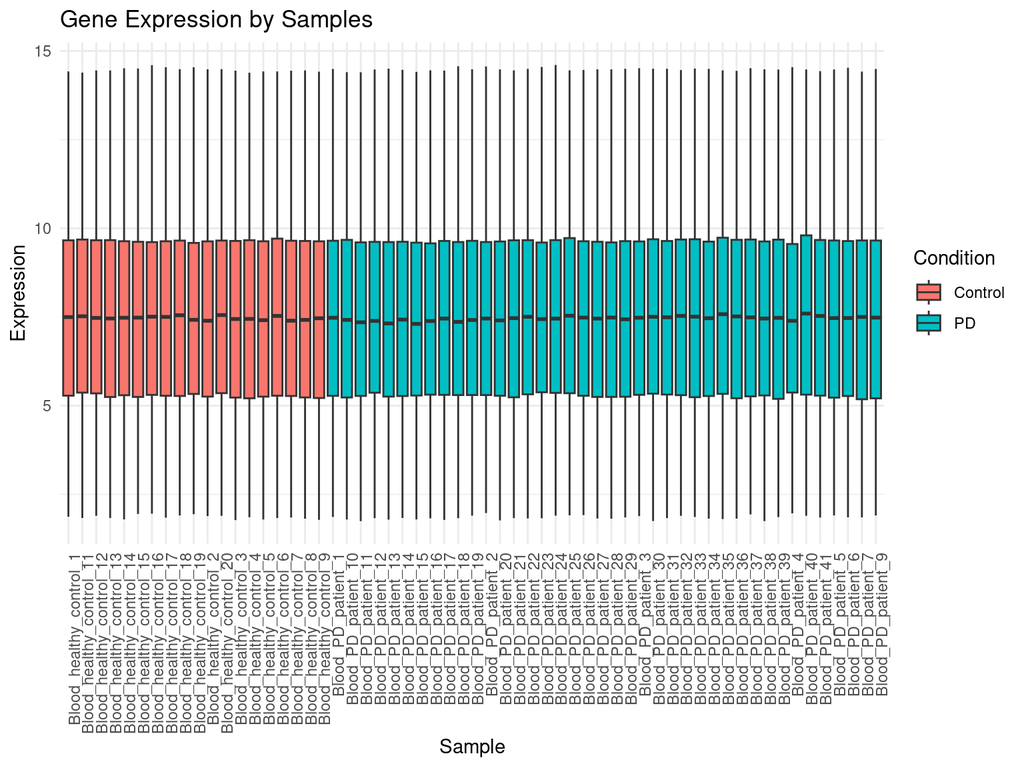

```r
# Create the boxplot to evaluate need for normalization and data spread
ggplot(df, aes(x = Sample, y = Expression, fill = Condition)) +
  geom_boxplot() +
  theme_minimal() +
  labs(title = "Gene Expression by Samples", x = "Sample", y = "Expression") +
  theme(axis.text.x = element_text(angle = 90, hjust = 1))
```

```r
ggsave("../results/02_normalization_check.png", width = 8, height = 6, dpi = 600)
```

## PCA

```r
library(tidyverse)
library(ggprism)

df <- read_tsv("../data/02_dat_clean.tsv")
```

```r
df_wider <- df %>%
  pivot_wider(
    names_from = Gene,
    values_from = Expression)

# Normalize - Center data
data_scaled <- apply(df_wider[, c(3:ncol(df_wider))], 2, function(x) (x - mean(x)) / sd(x))

PCA_data <- prcomp(t(data_scaled),
                   center = TRUE,
                   scale. = TRUE)

loadings <- prcomp(data_scaled,
                   center = TRUE,
                   scale. = TRUE) %>%
                   .$rotation

# Convert loadings to a tibble for tidyverse manipulation
loadings_tibble <- as_tibble(loadings, rownames = "Genes")

pca_data <- PCA_data$rotation %>% as.data.frame() %>%
  mutate(Condition = df_wider$Condition)

pca_data_summary <- pca_data %>%
  group_by(Condition) %>%
  summarise(sd_PC1 = sd(PC1),
            PC1 = mean(PC1),
            sd_PC2 = sd(PC2),
            PC2 = mean(PC2))

# Calculate the percentage of variance explained by each PC
variance_explained <- summary(PCA_data)$importance[3, ]
PC <- numeric(length(variance_explained))

for (i in seq_along(variance_explained)) {
  if (i == 1) {
    PC[i] <- round(variance_explained[i] * 100, 2)
  } else {
    PC[i] <- round(variance_explained[i] * 100, 2) - sum(PC[1:(i - 1)])
  }
}
```

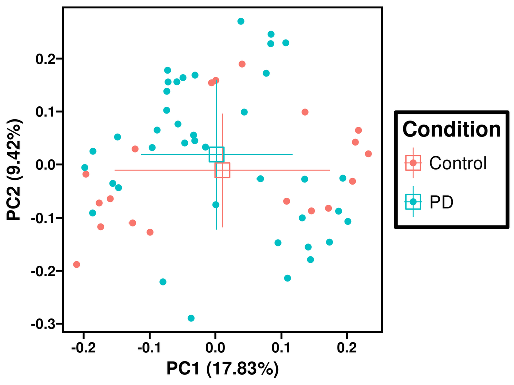

```r
# Plotting the PCA
ggplot(pca_data, aes(x = PC1, y = PC2, color = Condition)) +
  geom_point(size = 3) +
  geom_pointrange(data = pca_data_summary, aes(xmin = PC1 - sd_PC1, xmax = PC1 + sd_PC1), shape = 22, size = 2) +
  geom_pointrange(data = pca_data_summary, aes(ymin = PC2 - sd_PC2, ymax = PC2 + sd_PC2), shape = 22, size = 2) +
  theme_prism(border = TRUE, base_rect_size = 2) +
  labs(x = paste("PC1 (", PC[1], "%)", sep = ""),
       y = paste("PC2 (", PC[2], "%)", sep = "")) +
theme(legend.position = "right",
        panel.background = element_rect(fill='transparent'),
        plot.background = element_rect(fill='transparent', color=NA),
        panel.grid.major = element_blank(),
        panel.grid.minor = element_blank(),
        legend.background = element_rect(fill='transparent'),
        legend.box.background = element_rect(fill='transparent'),
        axis.title.x = element_text(size = 20),
        axis.title.y = element_text(size = 20),
        axis.text.x = element_text(size = 16),
        axis.text.y = element_text(size = 16),
        axis.text = element_text(size = 20),
        plot.title = element_text(size = 20, face = "bold"),
        legend.title = element_text(size = 24),
        legend.text = element_text(size = 20),
        legend.key.size = unit(3, "lines"),
        strip.text = element_text(size = 20))
```

```r
ggsave("../results/05_PCA_plot.png", width = 8, height = 6, dpi = 600)
```

# Looking for genes that are differential expressed

```r
library(broom)
library(tidyverse)

df_long <- read_tsv("../data/02_dat_clean.tsv")
```

```r
df_nested_exp <- df_long |>
  mutate(log2_exp = log2(Expression)) |> # transform data to log2
  group_by(Gene) |>
  nest() |>
  mutate(model_object = map(data, ~lm(log2_exp ~
                                      Condition, data = .x))) |>
  mutate(model_object_tidy = map(model_object, ~ tidy(.x, conf.int = TRUE,
                                                      conf.level = 0.95)))

#Fitting Linear models and extract the
df_est <- df_nested_exp |>
  unnest(model_object_tidy) |>
  filter(term == "ConditionPD") |>
  dplyr::select(Gene, estimate, std.error, statistic, p.value, conf.low, conf.high) |>
  ungroup() |>
  mutate(q.value = p.adjust(p.value),
  is_significant = if_else(q.value < 0.05, "Yes", "No"))
```

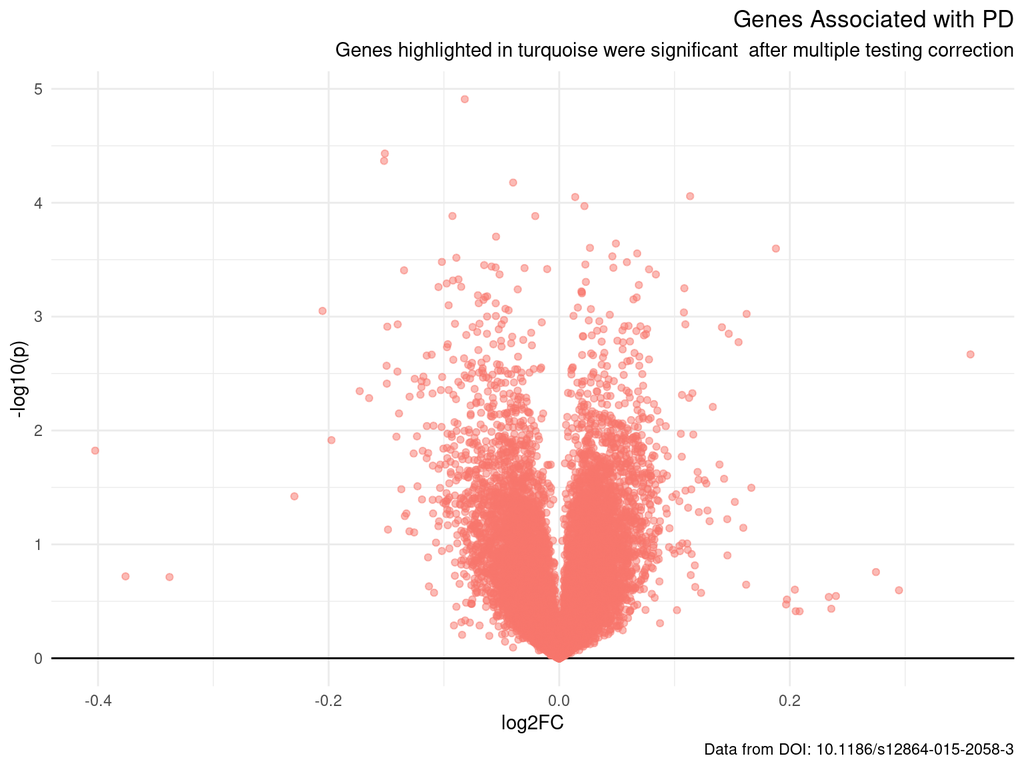

```r
# Generate volcano plot
ggplot(df_est, aes(estimate,
                   -log10(p.value),
                   color = is_significant)) +
  geom_hline(yintercept = 0) +
  geom_point(alpha = .5) +
  ggrepel::geom_text_repel(data = filter(df_est, is_significant == "Yes"),
                           aes(label = Gene),
                           segment.size = 0.3,
                           size = 2,
                           max.overlaps = 100) +
  labs(title= "Genes Associated with PD",
       subtitle = paste("Genes highlighted in turquoise were significant ",
                        "after multiple testing correction"),
       caption = "Data from DOI: 10.1186/s12864-015-2058-3",
       x = "log2FC",
       y = "-log10(p)") +
  theme_minimal() +
  theme(
    legend.position = "none",
    plot.title = element_text(hjust = 1),
    plot.subtitle = element_text(hjust = 1))
```

```r
ggsave("../results/06_Volcano_plot_gene_exp.png", width = 8, height = 6, dpi = 600)
```

Using this approach, that is fitting linear models to the genes, no genes are identified as being differential expressed (at least not significantly).

```r
# Define source and destination
source_file <- "04_linear_models.html"
destination_dir <- "../results/"

# Ensure the destination directory exists
if (!dir.exists(destination_dir)) {
  dir.create(destination_dir, recursive = TRUE)
}

# Move the file
file.copy(source_file, file.path(destination_dir, source_file), overwrite = TRUE)
```

# Expression in Gene Sets

## Load Libraries and Augmented Data

```r
library(tidyverse)
library(viridis)
library(ggplot2)
```

```r
df <- read_tsv("../data/03_dat_aug.tsv")
```

In 03_augmentation.qmd, we calculated the mean gene expression for set of genes. In the following code we will analyse the results

## Visualize

### Different Expression of Gene Sets

In 03_augment.qmd we calculated the mean of some gene sets. #### Distribution and Boxplot

In the following chunks we compare the expression levels using density plots and boxplots. ##### Neurodegenerative Gene Set

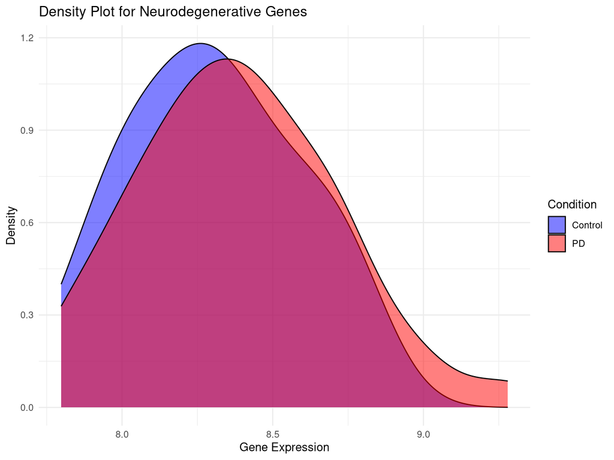

```r
# Plotting distribution
ggplot(data = df,
       aes(x = ndg_mean,
           fill = Condition)) +
  geom_density(alpha = 0.5) +  # alpha controls transparency
  labs(title = "Density Plot for Neurodegenerative Genes",
       x = "Gene Expression",
       y = "Density") +
  scale_fill_manual(values = c("Control" = "blue", "PD" = "red")) +
  theme_minimal()
```

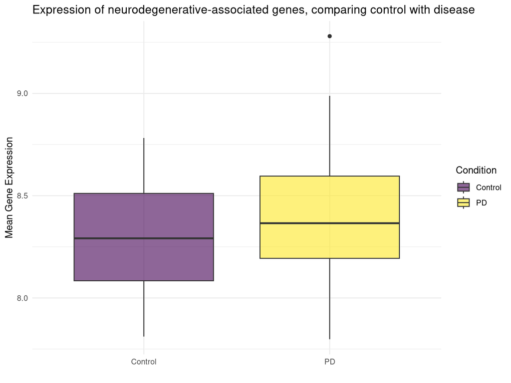

```r
ggsave("../results/07_neurodeg_density.png", width = 8, height = 6, dpi = 600, bg = "white")


df %>%
  ggplot(aes(x=Condition, y=ndg_mean, fill=Condition)) +
  geom_boxplot() +
  scale_fill_viridis(discrete = TRUE, alpha=0.6) +
  labs(y = "Mean Gene Expression") +
  theme(
    legend.position="none",
    plot.title = element_text(size=11)
  ) +
  ggtitle("Expression of neurodegenerative-associated genes, comparing control with disease") +
  xlab("") +
  theme_minimal()
```

```r
ggsave("../results/07_neurodeg_boxplot.png", width = 8, height = 6, dpi = 600, bg = "white")
```

##### Pro-inflammatory cytokines and chemokines

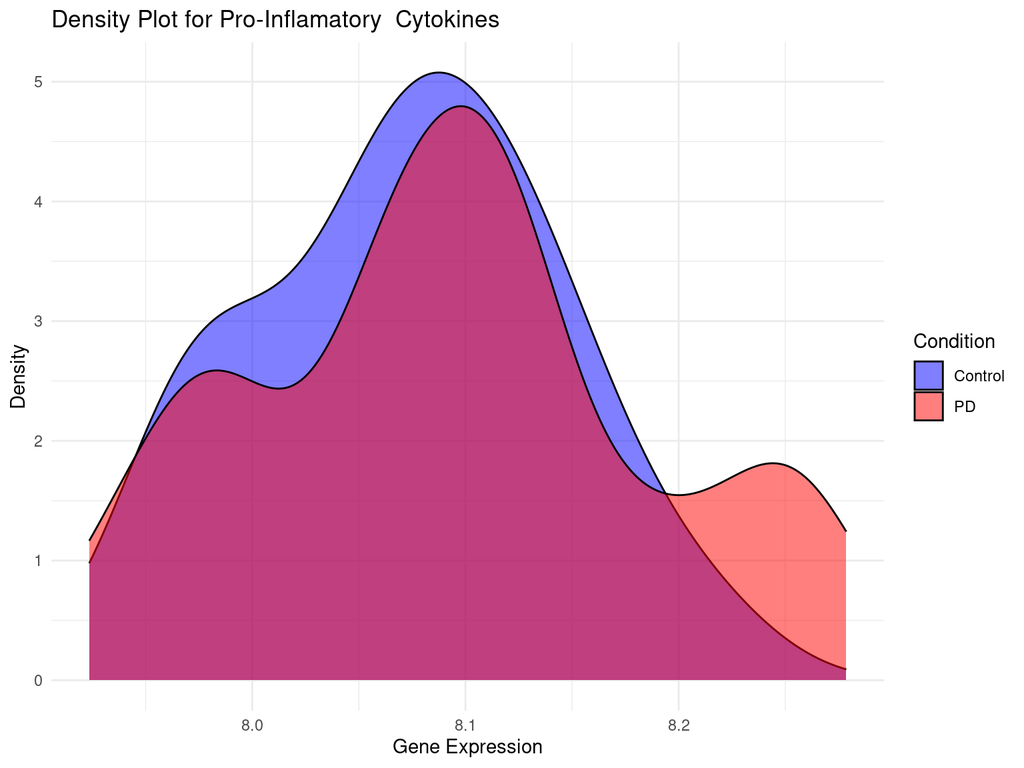

```r
# Plotting distribution
ggplot(df, aes(x = inflam_mean, fill = Condition)) +
  geom_density(alpha = 0.5) +  # alpha controls transparency
  labs(title = "Density Plot for Pro-Inflamatory  Cytokines",
       x = "Gene Expression", y = "Density") +
  scale_fill_manual(values = c("Control" = "blue", "PD" = "red")) +
  theme_minimal()
```

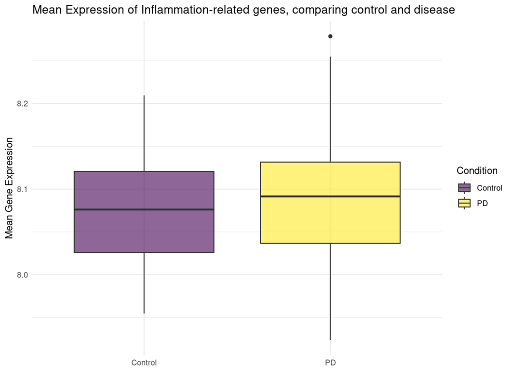

```r
ggsave("../results/07_inflammatory_density.png", width = 8, height = 6, dpi = 600, bg="white")

# Boxplot
df %>%
  ggplot(aes(x=Condition, y=inflam_mean, fill=Condition)) +
  geom_boxplot() +
  scale_fill_viridis(discrete = TRUE, alpha=0.6) +
  labs(y = "Mean Gene Expression") +
  theme(
    legend.position="none",
    plot.title = element_text(size=11)
  ) +
  ggtitle("Mean Expression of Inflammation-related genes, comparing control and disease") +
  xlab("") +
  theme_minimal()
```

```r
ggsave("../results/07_inflammatory_boxplot.png", width = 8, height = 6, dpi = 600, bg = "white")
```

## Interpretation - Statistical relevance

In the first boxplot, showing the different mean expression level for neurodegenerative-associated genes, a slight difference is visible. The second boxplot already shows less difference. The plots are a good and quick way to understand the data better, but if there is a significant difference is hard to see, so in the next chunk we look at the statistical relevance of the difference, by calculating the p-value.

```r
t_test_result <- t.test(ndg_mean ~ Condition, data = df)

print(t_test_result)
```

```
    Welch Two Sample t-test

data:  ndg_mean by Condition
t = -0.94302, df = 40.909, p-value = 0.3512
alternative hypothesis: true difference in means between group Control and group PD is not equal to 0
95 percent confidence interval:
 -0.24801228  0.09012837
sample estimates:
mean in group Control      mean in group PD
             8.305568              8.384510
```

```r
t_test_result <- t.test(inflam_mean ~ Condition, data = df)

print(t_test_result)
```

```
    Welch Two Sample t-test

data:  inflam_mean by Condition
t = -0.94823, df = 45.989, p-value = 0.348
alternative hypothesis: true difference in means between group Control and group PD is not equal to 0
95 percent confidence interval:
 -0.06496395  0.02335791
sample estimates:
mean in group Control      mean in group PD
             8.072247              8.093050
```

Both test showed us that there is no statistical relevance, with the p value being even higher then 0.3, and 0 being included in the 95% confidence interval.